# Administrative efficiency

Viktoriia Poltoratskaia

2025-12-04

This R Markdown document presents an initial draft of the analysis on administrative efficiency. It is based on ProAct open data for Uruguay and Bulgaria, with Uruguay serving as the baseline example. Data from Bulgaria are incorporated in instances where key variables are missing from the Uruguayan dataset.The underlying code is more extensive and detailed than the outputs presented here.

## Share of procedure types by contract value

After the standardization process, three main types of non-missing procedures are present on Uruguay’s procurement platform: open procedures, restricted procedures, and direct awards.

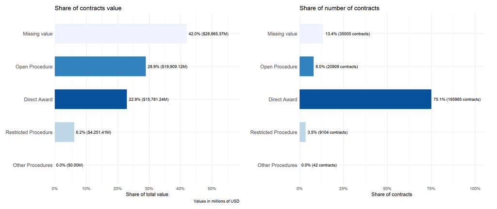

```r
combined <- sh + p_count + plot_layout(ncol = 2)
combined
```

```r
ggsave(
  filename = file.path(output_dir_uy, "share_value_vs_contracts.png"),
  plot     = combined,
  width    = 19,
  height   = 8,
  dpi      = 300
)
```

As shown, in terms of value share, the majority of non-missing contracts fall under the open procedure, followed by direct awards and restricted procedures. About 42% of contract values are missing information on the procedure type. However, when examining the number of contracts, the vast majority of records on the platform correspond to direct awards. This indicates that direct awards tend to have smaller values but make up most of the observations, whereas contracts with missing procedure information are few in number but large in value.

## Days between call for tender publication and bid deadline

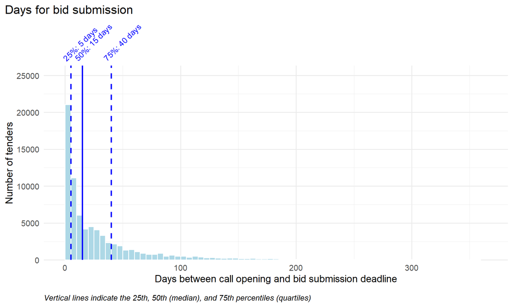

```r
subm=ggplot(tender_periods, aes(x = tender_days_open)) +
  geom_histogram(binwidth = 5, fill = "lightblue", color = "white", boundary = 0) +
  geom_vline(
    xintercept = q,
    color = "blue",
    linetype = c("dashed", "solid", "dashed"),
    size = 1
  ) +
  annotate(
    "text",
    x = q,
    y = Inf,
    label = paste0(names(q), ": ", round(q, 1), " days"),
    color = "blue",
    size = 4,
    angle = 45,
    vjust = -1,
    hjust = 0
  ) +
  coord_cartesian(xlim = c(0, 365), clip = "off") +
  scale_y_continuous(expand = expansion(mult = c(0, 0.25))) +
  labs(
    title = "Days for bid submission",
    x = "Days between call opening and bid submission deadline",
    y = "Number of tenders",
    caption = "Vertical lines indicate the 25th, 50th (median), and 75th percentiles (quartiles)"
  ) +
  theme_minimal(base_size = 14) +
  theme(
    plot.title.position = "plot",
    plot.title = element_text(margin = margin(b = 70)),
    plot.caption = element_text(hjust = 0, face = "italic", size = 11, margin = margin(t = 15))
  )
subm
```

```r
ggsave(
  filename = file.path(output_dir_uy, "subm.png"),
  plot     = subm,
  width    = 10,
  height   = 6,
  dpi      = 300
)
```

## Days between call for tender publication and bid deadline by procedure type

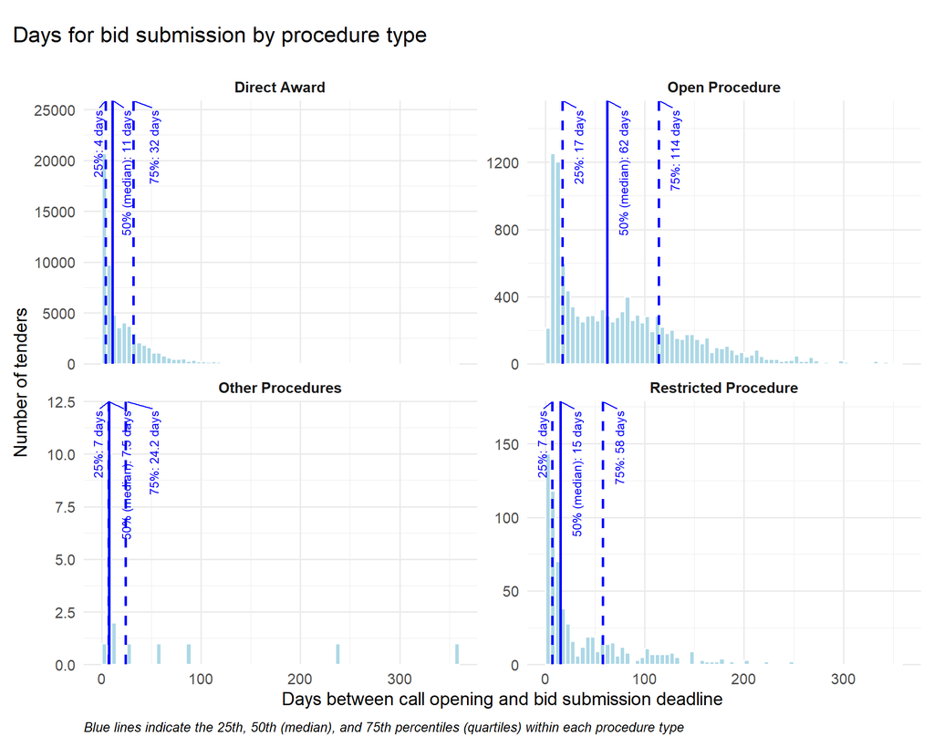

```r
tender_periods <- tender_periods %>%
  mutate(
    tender_proceduretype = recode(
      tender_proceduretype,
      "OPEN"            = "Open Procedure",
      "OUTRIGHT_AWARD"  = "Direct Award",
      "RESTRICTED"      = "Restricted Procedure",
      "OTHER"           = "Other Procedures",
      "COMPETITIVE_DIALOG" = "Competitive Dialog",
      "NEGOTIATED" = "Negotiated",
      "NEGOTIATED_WITHOUT_PUBLICATION" = "Negotiated without publications",
      "NEGOTIATED_WITH_PUBLICATION" = "Negotiated with publications"

    )
  )%>%
  drop_na(tender_proceduretype)

# 1. Compute quartiles per procedure type
q_by_proc <- tender_periods %>%
  group_by(tender_proceduretype) %>%
  summarise(
    q25 = quantile(tender_days_open, 0.25, na.rm = TRUE),
    q50 = quantile(tender_days_open, 0.50, na.rm = TRUE),
    q75 = quantile(tender_days_open, 0.75, na.rm = TRUE),
    .groups = "drop"
  ) %>%
  pivot_longer(
    cols = starts_with("q"),
    names_to = "quartile",
    values_to = "xint"
  ) %>%
  mutate(
    quartile_label = case_when(
      quartile == "q25" ~ "25%",
      quartile == "q50" ~ "50% (median)",
      quartile == "q75" ~ "75%",
      TRUE ~ quartile
    ),
    linetype = case_when(
      quartile == "q50" ~ "solid",
      TRUE              ~ "dashed"
    )
  )

# 2. Faceted histogram with per-facet quartile lines & labels
subm_proc_facet_q <- ggplot(tender_periods,
                            aes(x = tender_days_open)) +
  geom_histogram(
    binwidth  = 5,
    fill      = "lightblue",
    color     = "white",
    boundary  = 0
  ) +
  # Quartile lines per facet
  geom_vline(
    data  = q_by_proc,
    aes(xintercept = xint, linetype = quartile_label),
    color = "blue",
    size  = 0.9
  ) +
  # Quartile labels per facet
  geom_text_repel(
    data = q_by_proc,
    aes(
      x = xint,
      y = Inf,  # start at the top
      label = paste0(quartile_label, ": ", round(xint, 1), " days")
    ),
    inherit.aes        = FALSE,
    color              = "blue",
    size               = 3.3,
    angle              = 90,
    vjust              = 1.2,       # a little above the top of the panel
    min.segment.length = 0,
    segment.color      = "blue",
    box.padding        = 0.5,
    direction          = "x",       # 👈 allow horizontal movement to avoid overlap
    max.overlaps       = Inf        # don't drop labels
  ) +
  facet_wrap(~ tender_proceduretype, scales = "free_y") +
  scale_y_continuous(
    expand = expansion(mult = c(0, 0.25))
    # 👆 adds 25% extra space above the tallest bar in each facet
  ) +
  coord_cartesian(clip = "off") +   # still needed so labels can go a bit out
  scale_linetype_manual(
    name   = NULL,
    values = c(
      "25%"           = "dashed",
      "50% (median)"  = "solid",
      "75%"           = "dashed"
    )
  ) +
  labs(
    title   = "Days for bid submission by procedure type",
    x       = "Days between call opening and bid submission deadline",
    y       = "Number of tenders",
    caption = "Blue lines indicate the 25th, 50th (median), and 75th percentiles (quartiles) within each procedure type"
  ) +
  theme_minimal(base_size = 14) +
  theme(
    plot.title.position = "plot",
    plot.title          = element_text(margin = margin(b = 20)),
    plot.caption        = element_text(hjust = 0, face = "italic", size = 10,
                                       margin = margin(t = 10)),
    strip.text          = element_text(face = "bold"),
    legend.position     = "none",
    plot.margin         = margin(t = 20, r = 10, b = 10, l = 10)
  )

subm_proc_facet_q
```

```r
ggsave(
  filename = file.path(output_dir_uy, "subm_proc_fac.png"),
  plot     = subm_proc_facet_q,
  width    = 10,
  height   = 6,
  dpi      = 300
)
```

## Too short dates by procedure type

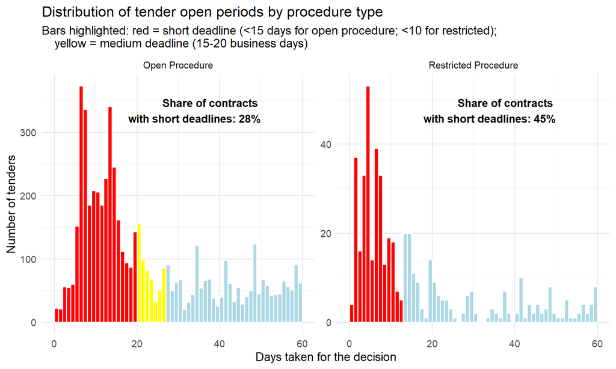

```r
subm_r=subm_r +
  geom_text(
    data = share_labels,
    aes(
      x = 50, y = Inf,
      label = paste0(
        "Share of contracts
        with short deadlines: ",
        round(share_short, 1), "%"
      )
    ),
    vjust = 2, hjust = 1,
    size = 4.5,
    fontface = "bold",
    inherit.aes = FALSE
  )

subm_r
```

```r
ggsave(
  filename = file.path(output_dir_uy, "subm_r.png"),
  plot     = subm_r,
  width    = 10,
  height   = 6,
  dpi      = 300
)
```

## Shares by buyers

[figure not shown]

```r
# --- 3) Combined plot & save -----------------------------------------------
combined_plot <- buyer_short + buyer_short_v +
  plot_layout(nrow = 2)  # stacked; use nrow = 1 for side-by-side

combined_plot
```

```r
ggsave(
  filename = file.path(output_dir_uy, "short_submission_buyer.png"),
  plot     = combined_plot,
  width    = 12,
  height   = 12,
  dpi      = 300
)
```

## Days between submission deadline and award date

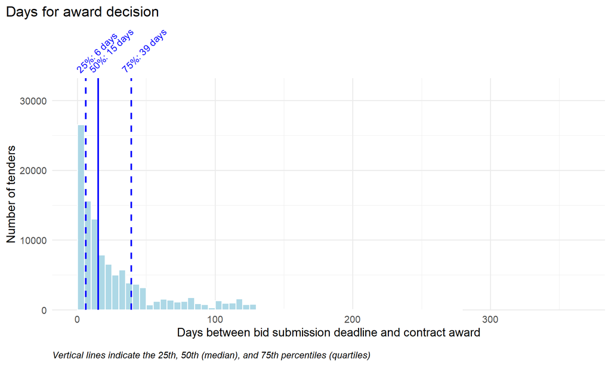

```r
tender_periods <- uy_proact %>%
  mutate(
    tender_biddeadline = as.Date(tender_biddeadline),
    tender_awarddecisiondate = as.Date(tender_awarddecisiondate)
  ) %>%
  filter(!is.na(tender_biddeadline), !is.na(tender_awarddecisiondate)) %>%
  mutate(
    tender_days_dec = as.numeric(tender_awarddecisiondate - tender_biddeadline)
  ) %>%
  filter(tender_days_dec >= 0 & tender_days_dec<365)
# Calculate quantiles
q <- quantile(tender_periods$tender_days_dec, probs = c(0.25, 0.5, 0.75), na.rm = TRUE)

decp=ggplot(tender_periods, aes(x = tender_days_dec)) +
  geom_histogram(binwidth = 5, fill = "lightblue", color = "white", boundary = 0) +
  geom_vline(
    xintercept = q,
    color = "blue",
    linetype = c("dashed", "solid", "dashed"),
    size = 1
  ) +
  annotate(
    "text",
    x = q,
    y = Inf,
    label = paste0(names(q), ": ", round(q, 1), " days"),
    color = "blue",
    size = 4,
    angle = 45,
    vjust = -1,
    hjust = 0
  ) +
  coord_cartesian(xlim = c(0, 365), clip = "off") +
  scale_y_continuous(expand = expansion(mult = c(0, 0.25))) +
  labs(
    title = "Days for award decision",
    x = "Days between bid submission deadline and contract award",
    y = "Number of tenders",
    caption = "Vertical lines indicate the 25th, 50th (median), and 75th percentiles (quartiles)"
  ) +
  theme_minimal(base_size = 14) +
  theme(
    plot.title.position = "plot",
    plot.title = element_text(margin = margin(b = 70)),
    plot.caption = element_text(hjust = 0, face = "italic", size = 11, margin = margin(t = 15))
  )
decp
```

```r
ggsave(
  filename = file.path(output_dir_uy, "decp.png"),
  plot     = decp,
  width    = 10,
  height   = 6,
  dpi      = 300
)
```

## Days between submission deadline and award date by procedure type

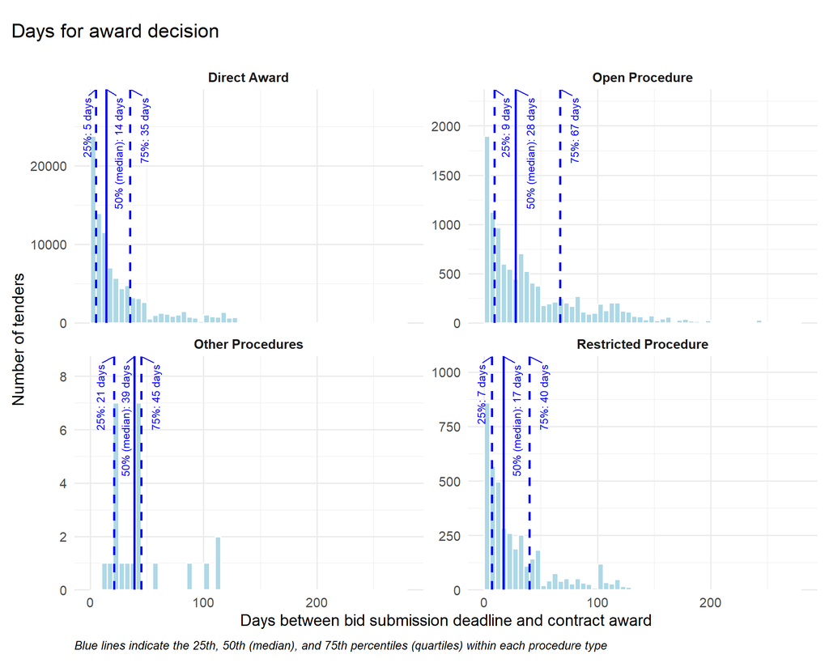

```r
# 2. Faceted histogram with per-facet quartile lines & labels
decp_proc_facet_q <- ggplot(tender_periods,
                            aes(x = tender_days_dec)) +
  geom_histogram(
    binwidth  = 5,
    fill      = "lightblue",
    color     = "white",
    boundary  = 0
  ) +
  # Quartile lines per facet
  geom_vline(
    data  = q_by_proc,
    aes(xintercept = xint, linetype = quartile_label),
    color = "blue",
    size  = 0.9
  ) +
  # Quartile labels per facet
  geom_text_repel(
    data = q_by_proc,
    aes(
      x = xint,
      y = Inf,  # start at the top
      label = paste0(quartile_label, ": ", round(xint, 1), " days")
    ),
    inherit.aes        = FALSE,
    color              = "blue",
    size               = 3.3,
    angle              = 90,
    vjust              = 1.2,       # a little above the top of the panel
    min.segment.length = 0,
    segment.color      = "blue",
    box.padding        = 0.5,
    direction          = "x",       # 👈 allow horizontal movement to avoid overlap
    max.overlaps       = Inf        # don't drop labels
  ) +
  facet_wrap(~ tender_proceduretype, scales = "free_y") +
  scale_y_continuous(
    expand = expansion(mult = c(0, 0.25))
    # 👆 adds 25% extra space above the tallest bar in each facet
  ) +
  coord_cartesian(clip = "off") +   # still needed so labels can go a bit out
  scale_linetype_manual(
    name   = NULL,
    values = c(
      "25%"           = "dashed",
      "50% (median)"  = "solid",
      "75%"           = "dashed"
    )
  ) +
  labs(
    title = "Days for award decision",
    x = "Days between bid submission deadline and contract award",
    y       = "Number of tenders",
    caption = "Blue lines indicate the 25th, 50th (median), and 75th percentiles (quartiles) within each procedure type"
  ) +
  theme_minimal(base_size = 14) +
  theme(
    plot.title.position = "plot",
    plot.title          = element_text(margin = margin(b = 20)),
    plot.caption        = element_text(hjust = 0, face = "italic", size = 10,
                                       margin = margin(t = 10)),
    strip.text          = element_text(face = "bold"),
    legend.position     = "none",
    plot.margin         = margin(t = 20, r = 10, b = 10, l = 10)
  )

decp_proc_facet_q
```

```r
ggsave(
  filename = file.path(output_dir_uy, "decp_proc_fac.png"),
  plot     = decp_proc_facet_q,
  width    = 10,
  height   = 6,
  dpi      = 300
)
```

## Too lengthy decisions by procedure type

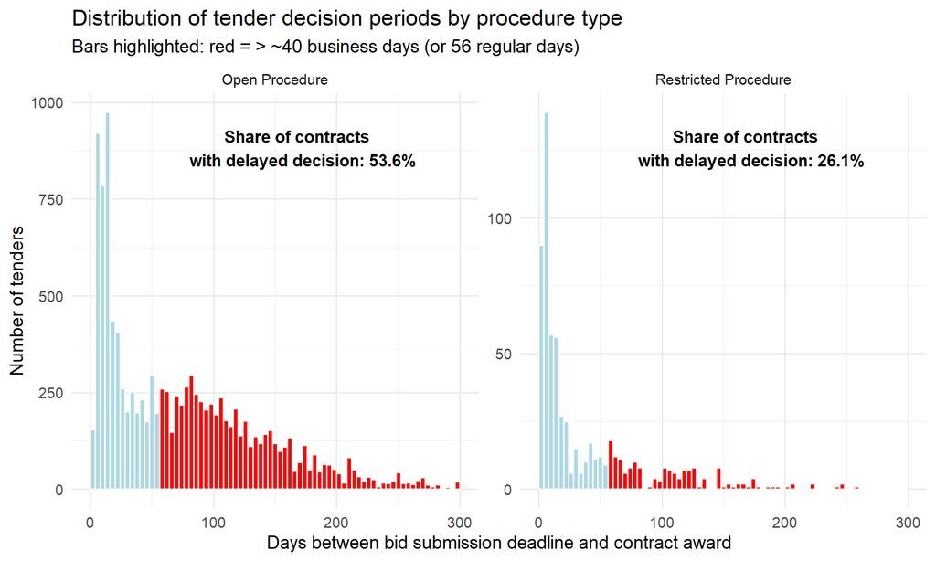

```r
# Add the text labels to your existing ggplot
decp_r +
  geom_text(
    data = share_labels,
    aes(
      x = 200, y = Inf,
      label = paste0("Share of contracts
                     with delayed decision: ", round(share_56, 1), "%")
    ),
    vjust = 2, hjust = 0.75,
    size = 4.5,
    fontface = "bold",
    inherit.aes = FALSE
  )
```

```r
ggsave(
  filename = file.path(output_dir_uy, "decp_r.png"),
  plot     = decp_r,
  width    = 10,
  height   = 6,
  dpi      = 300
)
```

## Share of delayed decisions by buyer type

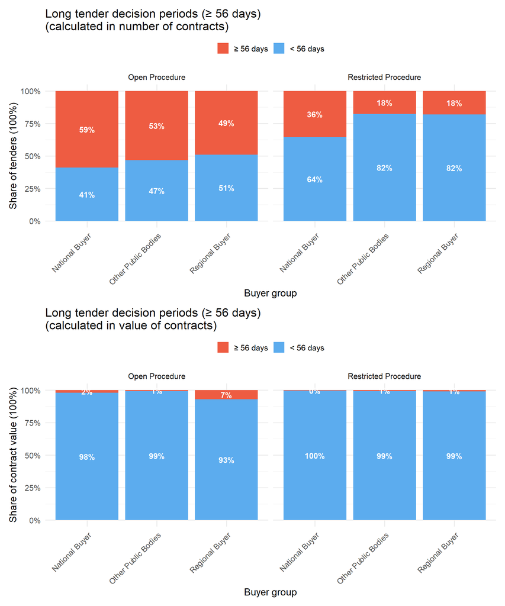

```r
# 3) Combined plot (number vs value) ----------------------------------------
combined_dec_plot <- buyer_long + buyer_long_v +
  plot_layout(nrow = 2)  # stacked; use nrow = 1 for side-by-side

combined_dec_plot
```

```r
ggsave(
  filename = file.path(output_dir_uy, "long_decision_buyer.png"),
  plot     = combined_dec_plot,
  width    = 12,
  height   = 12,
  dpi      = 300
)
```